# Into the Tidyverse

Session Three Solutions

As always, we start by loading the tidyverse package.

```r
library(tidyverse)
```

## Back to the Basics

### Arithmetic with Boolean Values

#### Part 1

```r
5 + TRUE
```

```
[1] 6
```

Under-the-hood, `TRUE` is stored as `1`, and so when we use `TRUE` in an arithmetic operation, it gets converted to this numeric form.

#### Part 2

Likewise `FALSE` is stored as `0` so `5 + FALSE` is `5`.

#### Part 3

Since `TRUE` represents `1` and `FALSE` represents `0`, the sum of a logical vector will return the number of `TRUE` values.

#### Part 4

Similar to before, but `mean()` will give the proportion of true values.

#### Part 5

`FALSE < TRUE` is the same as `0 < 1` which is clearly true. This means that `FALSE` values will be sorted before `TRUE` values by default when we use `arrange()`.

## The dpylr verbs

### Filter

#### Part 1

```r
filter(diamonds, price == max(price))
```

| carat | cut | color | clarity | depth | table | price | x | y | z |
| --- | --- | --- | --- | --- | --- | --- | --- | --- | --- |
| 2.29 | Premium | I | VS2 | 60.8 | 60 | 18823 | 8.5 | 8.47 | 5.16 |

The highest price is $18,823 (currency obtained from `?diamonds`) and the carat of this diamond is 2.29.

#### Part 2

```r
mpg_grpd <- group_by(mpg, year)
filter(mpg_grpd, displ == min(displ))
```

| manufacturer | model | displ | year | cyl | trans | drv | cty | hwy | fl | class |
| --- | --- | --- | --- | --- | --- | --- | --- | --- | --- | --- |
| honda | civic | 1.6 | 1999 | 4 | manual(m5) | f | 28 | 33 | r | subcompact |
| honda | civic | 1.6 | 1999 | 4 | auto(l4) | f | 24 | 32 | r | subcompact |
| honda | civic | 1.6 | 1999 | 4 | manual(m5) | f | 25 | 32 | r | subcompact |
| honda | civic | 1.6 | 1999 | 4 | manual(m5) | f | 23 | 29 | p | subcompact |
| honda | civic | 1.6 | 1999 | 4 | auto(l4) | f | 24 | 32 | r | subcompact |
| honda | civic | 1.8 | 2008 | 4 | manual(m5) | f | 26 | 34 | r | subcompact |
| honda | civic | 1.8 | 2008 | 4 | auto(l5) | f | 25 | 36 | r | subcompact |
| honda | civic | 1.8 | 2008 | 4 | auto(l5) | f | 24 | 36 | c | subcompact |
| toyota | corolla | 1.8 | 2008 | 4 | manual(m5) | f | 28 | 37 | r | compact |
| toyota | corolla | 1.8 | 2008 | 4 | auto(l4) | f | 26 | 35 | r | compact |

Note that we could have used a pipe (`%>%`) instead of creating `mpg_grpd`.

#### Part 3

```r
filter(iris, Petal.Length > 6.4 | Petal.Width > 2.4)
```

| Sepal.Length | Sepal.Width | Petal.Length | Petal.Width | Species |
| --- | --- | --- | --- | --- |
| 6.3 | 3.3 | 6.0 | 2.5 | virginica |
| 7.6 | 3.0 | 6.6 | 2.1 | virginica |
| 7.2 | 3.6 | 6.1 | 2.5 | virginica |
| 7.7 | 3.8 | 6.7 | 2.2 | virginica |
| 7.7 | 2.6 | 6.9 | 2.3 | virginica |
| 7.7 | 2.8 | 6.7 | 2.0 | virginica |
| 6.7 | 3.3 | 5.7 | 2.5 | virginica |

### Arrange

#### Part 1

We actually don’t need to print the tables. The function `glimpse()` will give us these types.

```r
glimpse(mpg)
```

```
Rows: 234
Columns: 11
$ manufacturer <chr> "audi", "audi", "audi", "audi", "audi", "audi", "audi",...
$ model        <chr> "a4", "a4", "a4", "a4", "a4", "a4", "a4", "a4 quattro",...
$ displ        <dbl> 1.8, 1.8, 2.0, 2.0, 2.8, 2.8, 3.1, 1.8, 1.8, 2.0, 2.0, ...
$ year         <int> 1999, 1999, 2008, 2008, 1999, 1999, 2008, 1999, 1999, 2...
$ cyl          <int> 4, 4, 4, 4, 6, 6, 6, 4, 4, 4, 4, 6, 6, 6, 6, 6, 6, 8, 8...
$ trans        <chr> "auto(l5)", "manual(m5)", "manual(m6)", "auto(av)", "au...
$ drv          <chr> "f", "f", "f", "f", "f", "f", "f", "4", "4", "4", "4", ...
$ cty          <int> 18, 21, 20, 21, 16, 18, 18, 18, 16, 20, 19, 15, 17, 17,...
$ hwy          <int> 29, 29, 31, 30, 26, 26, 27, 26, 25, 28, 27, 25, 25, 25,...
$ fl           <chr> "p", "p", "p", "p", "p", "p", "p", "p", "p", "p", "p", ...
$ class        <chr> "compact", "compact", "compact", "compact", "compact", ...
```

```r
glimpse(diamonds)
```

```
Rows: 53,940
Columns: 10
$ carat   <dbl> 0.23, 0.21, 0.23, 0.29, 0.31, 0.24, 0.24, 0.26, 0.22, 0.23, ...
$ cut     <ord> Ideal, Premium, Good, Premium, Good, Very Good, Very Good, V...
$ color   <ord> E, E, E, I, J, J, I, H, E, H, J, J, F, J, E, E, I, J, J, J, ...
$ clarity <ord> SI2, SI1, VS1, VS2, SI2, VVS2, VVS1, SI1, VS2, VS1, SI1, VS1...
$ depth   <dbl> 61.5, 59.8, 56.9, 62.4, 63.3, 62.8, 62.3, 61.9, 65.1, 59.4, ...
$ table   <dbl> 55, 61, 65, 58, 58, 57, 57, 55, 61, 61, 55, 56, 61, 54, 62, ...
$ price   <int> 326, 326, 327, 334, 335, 336, 336, 337, 337, 338, 339, 340, ...
$ x       <dbl> 3.95, 3.89, 4.05, 4.20, 4.34, 3.94, 3.95, 4.07, 3.87, 4.00, ...
$ y       <dbl> 3.98, 3.84, 4.07, 4.23, 4.35, 3.96, 3.98, 4.11, 3.78, 4.05, ...
$ z       <dbl> 2.43, 2.31, 2.31, 2.63, 2.75, 2.48, 2.47, 2.53, 2.49, 2.39, ...
```

`class` is a character variable and so this column will be ordered alphabetically. Meanwhile, `cut` is an ordinal (ordered) variable and so will be ordered in the same way as the undersying order assigned to the column.

#### Part 2

```r
arrange(mpg, hwy - cty)
```

| manufacturer | model | displ | year | cyl | trans | drv | cty | hwy | fl | class |
| --- | --- | --- | --- | --- | --- | --- | --- | --- | --- | --- |
| nissan | pathfinder 4wd | 3.3 | 1999 | 6 | manual(m5) | 4 | 15 | 17 | r | suv |
| toyota | 4runner 4wd | 3.4 | 1999 | 6 | manual(m5) | 4 | 15 | 17 | r | suv |
| toyota | toyota tacoma 4wd | 3.4 | 1999 | 6 | manual(m5) | 4 | 15 | 17 | r | pickup |
| chevrolet | k1500 tahoe 4wd | 5.3 | 2008 | 8 | auto(l4) | 4 | 11 | 14 | e | suv |
| chevrolet | k1500 tahoe 4wd | 6.5 | 1999 | 8 | auto(l4) | 4 | 14 | 17 | d | suv |
| dodge | dakota pickup 4wd | 3.9 | 1999 | 6 | manual(m5) | 4 | 14 | 17 | r | pickup |
| dodge | dakota pickup 4wd | 4.7 | 2008 | 8 | auto(l5) | 4 | 9 | 12 | e | pickup |
| dodge | durango 4wd | 4.7 | 2008 | 8 | auto(l5) | 4 | 9 | 12 | e | suv |
| dodge | ram 1500 pickup 4wd | 4.7 | 2008 | 8 | auto(l5) | 4 | 9 | 12 | e | pickup |
| dodge | ram 1500 pickup 4wd | 4.7 | 2008 | 8 | manual(m6) | 4 | 9 | 12 | e | pickup |

[output cut: 224 more lines]

### Select

#### Part 1

```r
select(diamonds, -price)
```

| carat | cut | color | clarity | depth | table | x | y | z |
| --- | --- | --- | --- | --- | --- | --- | --- | --- |
| 0.23 | Ideal | E | SI2 | 61.5 | 55.0 | 3.95 | 3.98 | 2.43 |
| 0.21 | Premium | E | SI1 | 59.8 | 61.0 | 3.89 | 3.84 | 2.31 |
| 0.23 | Good | E | VS1 | 56.9 | 65.0 | 4.05 | 4.07 | 2.31 |
| 0.29 | Premium | I | VS2 | 62.4 | 58.0 | 4.20 | 4.23 | 2.63 |
| 0.31 | Good | J | SI2 | 63.3 | 58.0 | 4.34 | 4.35 | 2.75 |
| 0.24 | Very Good | J | VVS2 | 62.8 | 57.0 | 3.94 | 3.96 | 2.48 |
| 0.24 | Very Good | I | VVS1 | 62.3 | 57.0 | 3.95 | 3.98 | 2.47 |
| 0.26 | Very Good | H | SI1 | 61.9 | 55.0 | 4.07 | 4.11 | 2.53 |
| 0.22 | Fair | E | VS2 | 65.1 | 61.0 | 3.87 | 3.78 | 2.49 |
| 0.23 | Very Good | H | VS1 | 59.4 | 61.0 | 4.00 | 4.05 | 2.39 |

[output cut: 990 more lines]

#### Part 2

Select the 1st, 2nd, 4th, and 11th column of the `mpg` dataset.

### Mutate

#### Part 1

N/A

#### Part 2

```r
mutate(mpg, trans = factor(trans))
```

| manufacturer | model | displ | year | cyl | trans | drv | cty | hwy | fl | class |
| --- | --- | --- | --- | --- | --- | --- | --- | --- | --- | --- |
| audi | a4 | 1.8 | 1999 | 4 | auto(l5) | f | 18 | 29 | p | compact |
| audi | a4 | 1.8 | 1999 | 4 | manual(m5) | f | 21 | 29 | p | compact |
| audi | a4 | 2.0 | 2008 | 4 | manual(m6) | f | 20 | 31 | p | compact |
| audi | a4 | 2.0 | 2008 | 4 | auto(av) | f | 21 | 30 | p | compact |
| audi | a4 | 2.8 | 1999 | 6 | auto(l5) | f | 16 | 26 | p | compact |
| audi | a4 | 2.8 | 1999 | 6 | manual(m5) | f | 18 | 26 | p | compact |
| audi | a4 | 3.1 | 2008 | 6 | auto(av) | f | 18 | 27 | p | compact |
| audi | a4 quattro | 1.8 | 1999 | 4 | manual(m5) | 4 | 18 | 26 | p | compact |
| audi | a4 quattro | 1.8 | 1999 | 4 | auto(l5) | 4 | 16 | 25 | p | compact |
| audi | a4 quattro | 2.0 | 2008 | 4 | manual(m6) | 4 | 20 | 28 | p | compact |

[output cut: 224 more lines]

#### Part 3

```r
mutate(mpg, is_automatic = trans == 'auto(l5)')
```

| manufacturer | model | displ | year | cyl | trans | drv | cty | hwy | fl | class | is_automatic |
| --- | --- | --- | --- | --- | --- | --- | --- | --- | --- | --- | --- |
| audi | a4 | 1.8 | 1999 | 4 | auto(l5) | f | 18 | 29 | p | compact | TRUE |
| audi | a4 | 1.8 | 1999 | 4 | manual(m5) | f | 21 | 29 | p | compact | FALSE |
| audi | a4 | 2.0 | 2008 | 4 | manual(m6) | f | 20 | 31 | p | compact | FALSE |
| audi | a4 | 2.0 | 2008 | 4 | auto(av) | f | 21 | 30 | p | compact | FALSE |
| audi | a4 | 2.8 | 1999 | 6 | auto(l5) | f | 16 | 26 | p | compact | TRUE |
| audi | a4 | 2.8 | 1999 | 6 | manual(m5) | f | 18 | 26 | p | compact | FALSE |
| audi | a4 | 3.1 | 2008 | 6 | auto(av) | f | 18 | 27 | p | compact | FALSE |
| audi | a4 quattro | 1.8 | 1999 | 4 | manual(m5) | 4 | 18 | 26 | p | compact | FALSE |
| audi | a4 quattro | 1.8 | 1999 | 4 | auto(l5) | 4 | 16 | 25 | p | compact | TRUE |
| audi | a4 quattro | 2.0 | 2008 | 4 | manual(m6) | 4 | 20 | 28 | p | compact | FALSE |

[output cut: 224 more lines]

#### Part 4

```r
mpg_grpd <- group_by(mpg, class)
mutate(mpg_grpd, best_in_class = hwy == max(hwy))
```

| manufacturer | model | displ | year | cyl | trans | drv | cty | hwy | fl | class | best_in_class |
| --- | --- | --- | --- | --- | --- | --- | --- | --- | --- | --- | --- |
| audi | a4 | 1.8 | 1999 | 4 | auto(l5) | f | 18 | 29 | p | compact | FALSE |
| audi | a4 | 1.8 | 1999 | 4 | manual(m5) | f | 21 | 29 | p | compact | FALSE |
| audi | a4 | 2.0 | 2008 | 4 | manual(m6) | f | 20 | 31 | p | compact | FALSE |
| audi | a4 | 2.0 | 2008 | 4 | auto(av) | f | 21 | 30 | p | compact | FALSE |
| audi | a4 | 2.8 | 1999 | 6 | auto(l5) | f | 16 | 26 | p | compact | FALSE |
| audi | a4 | 2.8 | 1999 | 6 | manual(m5) | f | 18 | 26 | p | compact | FALSE |
| audi | a4 | 3.1 | 2008 | 6 | auto(av) | f | 18 | 27 | p | compact | FALSE |
| audi | a4 quattro | 1.8 | 1999 | 4 | manual(m5) | 4 | 18 | 26 | p | compact | FALSE |
| audi | a4 quattro | 1.8 | 1999 | 4 | auto(l5) | 4 | 16 | 25 | p | compact | FALSE |
| audi | a4 quattro | 2.0 | 2008 | 4 | manual(m6) | 4 | 20 | 28 | p | compact | FALSE |

[output cut: 224 more lines]

#### Part 5

```r
mutate(diamonds, expensive = price > quantile(price)[3])
```

| carat | cut | color | clarity | depth | table | price | x | y | z | expensive |
| --- | --- | --- | --- | --- | --- | --- | --- | --- | --- | --- |
| 0.23 | Ideal | E | SI2 | 61.5 | 55.0 | 326 | 3.95 | 3.98 | 2.43 | FALSE |
| 0.21 | Premium | E | SI1 | 59.8 | 61.0 | 326 | 3.89 | 3.84 | 2.31 | FALSE |
| 0.23 | Good | E | VS1 | 56.9 | 65.0 | 327 | 4.05 | 4.07 | 2.31 | FALSE |
| 0.29 | Premium | I | VS2 | 62.4 | 58.0 | 334 | 4.20 | 4.23 | 2.63 | FALSE |
| 0.31 | Good | J | SI2 | 63.3 | 58.0 | 335 | 4.34 | 4.35 | 2.75 | FALSE |
| 0.24 | Very Good | J | VVS2 | 62.8 | 57.0 | 336 | 3.94 | 3.96 | 2.48 | FALSE |
| 0.24 | Very Good | I | VVS1 | 62.3 | 57.0 | 336 | 3.95 | 3.98 | 2.47 | FALSE |
| 0.26 | Very Good | H | SI1 | 61.9 | 55.0 | 337 | 4.07 | 4.11 | 2.53 | FALSE |
| 0.22 | Fair | E | VS2 | 65.1 | 61.0 | 337 | 3.87 | 3.78 | 2.49 | FALSE |
| 0.23 | Very Good | H | VS1 | 59.4 | 61.0 | 338 | 4.00 | 4.05 | 2.39 | FALSE |

[output cut: 990 more lines]

### Summarise

#### Part 1

```r
summarise(iris,
          Petal.Length.Median = median(Petal.Length),
          Petal.Width.Median = median(Petal.Width),
          Sepal.Length.Median = median(Sepal.Length),
          Sepal.Width.Median = median(Sepal.Width))
```

| Petal.Length.Median | Petal.Width.Median | Sepal.Length.Median | Sepal.Width.Median |
| --- | --- | --- | --- |
| 4.35 | 1.3 | 5.8 | 3 |

There is actually an easier way to do this using `summarise_at()` though this set of functions can be quite difficult to get your head around.

#### Part 2

```r
diamonds %>%
  group_by(cut) %>%
  summarise(min(price))
```

| cut | min(price) |
| --- | --- |
| Fair | 337 |
| Good | 327 |
| Very Good | 336 |
| Premium | 326 |
| Ideal | 326 |

#### Part 3

```r
airquality %>%
  group_by(Month) %>%
  summarise(MeanOzone = mean(Ozone, na.rm = TRUE))
```

| Month | MeanOzone |
| --- | --- |
| 5 | 23.61538 |
| 6 | 29.44444 |
| 7 | 59.11538 |
| 8 | 59.96154 |
| 9 | 31.44828 |

#### Part 4

```r
diamonds %>%
  group_by(cut, color) %>%
  summarise(range = diff(range(carat)))
```

| cut | color | range |
| --- | --- | --- |
| Fair | D | 3.15 |
| Fair | E | 1.82 |
| Fair | F | 2.33 |
| Fair | G | 2.37 |
| Fair | H | 3.80 |
| Fair | I | 2.61 |
| Fair | J | 4.71 |
| Good | D | 1.81 |
| Good | E | 2.77 |
| Good | F | 2.44 |

[output cut: 25 more lines]

### Pipelines

#### Part 1

```r
mpg %>%
  filter(class != '2-seater') %>%
  mutate(efficiency = (cty + hwy) / 2) %>%
  group_by(manufacturer) %>%
  summarise(max_efficiency = max(efficiency)) %>%
  arrange(desc(max_efficiency))
```

| manufacturer | max_efficiency |
| --- | --- |
| volkswagen | 39.5 |
| toyota | 32.5 |
| honda | 30.5 |
| nissan | 27.5 |
| chevrolet | 26.0 |
| hyundai | 26.0 |
| audi | 25.5 |
| subaru | 23.5 |
| pontiac | 23.0 |
| ford | 22.0 |

[output cut: 5 more lines]

#### Part 2

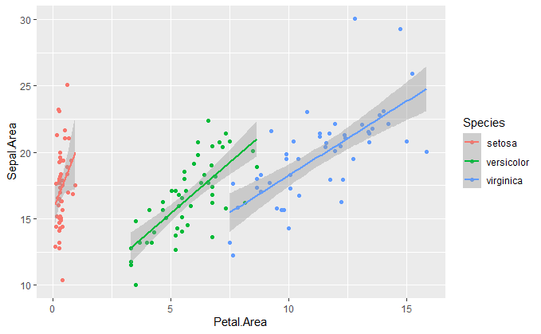

```r
iris %>%
  mutate(Petal.Area = Petal.Width * Petal.Length,
         Sepal.Area = Sepal.Width * Sepal.Length) %>%
  ggplot(aes(x = Petal.Area, y = Sepal.Area, col = Species)) +
    geom_point() +
    geom_smooth(method = 'lm')
```

#### Part 3

N/A

## Going Beyond

### Ranking

#### Part 1

Done.

#### Part 2

A dense rank makes the most sense here since we want to select all days with the second highest for each month.

```r
airquality %>%
  group_by(Month) %>%
  # low values have low rank so negate total_rainfall
  mutate(solar_rank = dense_rank(-Solar.R)) %>%
  filter(solar_rank == 2) %>%
  # optionally remove ranking column
  select(-solar_rank)
```

| Ozone | Solar.R | Wind | Temp | Month | Day |
| --- | --- | --- | --- | --- | --- |
| 30 | 322 | 11.5 | 68 | 5 | 19 |
| 39 | 323 | 11.5 | 87 | 6 | 10 |
| NA | 295 | 11.5 | 82 | 7 | 23 |
| 21 | 259 | 15.5 | 77 | 8 | 21 |
| 20 | 252 | 10.9 | 80 | 9 | 7 |

#### Part 3

```r
mpg %>%
  group_by(year) %>%
  mutate(mileage_rank = dense_rank(cty)) %>%
  filter(mileage_rank == 1) %>%
  # we no longer need the rank column
  select(-mileage_rank)
```

| manufacturer | model | displ | year | cyl | trans | drv | cty | hwy | fl | class |
| --- | --- | --- | --- | --- | --- | --- | --- | --- | --- | --- |
| chevrolet | k1500 tahoe 4wd | 5.7 | 1999 | 8 | auto(l4) | 4 | 11 | 15 | r | suv |
| dodge | dakota pickup 4wd | 4.7 | 2008 | 8 | auto(l5) | 4 | 9 | 12 | e | pickup |
| dodge | dakota pickup 4wd | 5.2 | 1999 | 8 | manual(m5) | 4 | 11 | 17 | r | pickup |
| dodge | dakota pickup 4wd | 5.2 | 1999 | 8 | auto(l4) | 4 | 11 | 15 | r | pickup |
| dodge | durango 4wd | 4.7 | 2008 | 8 | auto(l5) | 4 | 9 | 12 | e | suv |
| dodge | durango 4wd | 5.2 | 1999 | 8 | auto(l4) | 4 | 11 | 16 | r | suv |
| dodge | durango 4wd | 5.9 | 1999 | 8 | auto(l4) | 4 | 11 | 15 | r | suv |
| dodge | ram 1500 pickup 4wd | 4.7 | 2008 | 8 | auto(l5) | 4 | 9 | 12 | e | pickup |
| dodge | ram 1500 pickup 4wd | 4.7 | 2008 | 8 | manual(m6) | 4 | 9 | 12 | e | pickup |
| dodge | ram 1500 pickup 4wd | 5.2 | 1999 | 8 | auto(l4) | 4 | 11 | 15 | r | pickup |

[output cut: 11 more lines]

### Un-grouping

#### Part 1

We recieve the error `` Error: Column `Class` can't be modified because it's a grouping variable ``.

#### Part 2

The error occurs when we run the `mutate` function.

#### Part 3

The problem is that we didn’t ungroup before applying the mutate. We are therefore still grouped by `Class` and `Age` which means that we are not allowed to modify either of these until we have ungrouped.